# Active Learning Practice

Tyler Iams

2/7/2019

# Overview

The goal of this project is to deploy the technique of active learning on a variety of datasets with one script. I will therefore need to make the technique flexible

```r
library(ggplot2)
library(tidyverse)
library(keras)
library(pROC)
library(glmnet)
library(feather)
library(reshape2)
```

# Data Gathering and Tidying

First Grab the mnist data

```r
# Read in the data
mnist <- dataset_mnist()
```

# Need to do some reshaping of their data

To achieve what we want to with active learning, we first train a model on nums 0-4, then use that model to featurize the nums 5-9. First we separate out the 0-4 and 5-9 into two datasets.

```r
train <- mnist$train
test <- mnist$test

train_set <- data.frame(x = train$x, y = train$y)
test_set <- data.frame(x = test$x, y = test$y)
```

Count how many 0-4 digits there are in each dataset

```r
train_set %>% count(y < 5)
```

```
## # A tibble: 2 x 2
##   `y < 5`     n
##   <lgl>   <int>
## 1 FALSE   29404
## 2 TRUE    30596
```

```r
test_set %>% count(y < 5)
```

```
## # A tibble: 2 x 2
##   `y < 5`     n
##   <lgl>   <int>
## 1 FALSE    4861
## 2 TRUE     5139
```

There are 30596 digits that are less than 5 in the train_set and 5139 digits less than 5 in the test_set

Separate the train_set into two groups (first lets create dataframes via matrices to allocate memory and avoid using rbind).

```r
mat0 <- matrix(nrow = 30596, ncol = 785)
mat01 <- matrix(nrow = 60000, ncol = 785)

zeroToFour <- data.frame(mat0)
fiveToNine <- data.frame(mat01)
count <- 0
realCount <- 0

for (x in 1:60000) {
  if (train_set[x,785] > 4) {
      fiveToNine[x,] <- train_set[x,]
      count = count + 1
      realCount = realCount + 1
      if (count == 100) {
        print(train_set[x,785])
        print(realCount)
        count = 0
      }
  }
}

fiveToNine <- fiveToNine %>% na.omit()
```

Separate the test_set into two groups the same way and then we’ll combine the two data frame groups.

```r
mat02 <- matrix(nrow = 5139, ncol = 785)
mat03 <- matrix(nrow = 4861, ncol = 785)

df2 <- data.frame(mat)
df02 <- data.frame(mat01)

for (x in 1:10000) {
  if (test_set[x,785] < 5) {
    df2[x,] <- test_set[x,]
  } else {
    df02[x,] <- test_set[x,]
  }
}

df2 <- df2 %>% na.omit()
df02 <- df02 %>% na.omit()

colnames(zeroToFour) <- colnames(df2)

colnames(fiveToNine) <- colnames(df02)

zeroToFour <- rbind(zeroToFour, df2)

fiveToNine <- rbind(fiveToNine, df02)

# clean up the mess
rm(df02)
rm(df2)
rm(mat0)
rm(mat01)
rm(mat02)
rm(mat03)

# now write them to file so we don't have to do this again
write_csv(zeroToFour, "zero_to_four.csv")
write_csv(fiveToNine, "five_to_nine.csv")
```

## Start Here if you’ve written to file already

```r
zeroToFour <- read_csv("zero_to_four.csv")
fiveToNine <- read_csv("five_to_nine.csv")
```

Next we need to separate into test and training sets

```r
nrow(zeroToFour)
```

```
## [1] 35735
```

```r
test_set_04 <- zeroToFour %>% sample_frac(.1)
train_set_04 <- zeroToFour %>% setdiff(test_set_04)
test_set_59 <- fiveToNine %>% sample_frac(.1)
train_set_59 <- fiveToNine %>% setdiff(test_set_59)
```

# We are only going to train a model on 0-4 at first, then we will extract the features and train a ridge regression model on those to see how it performs

```r
# Put these into matrices
train_set_04_targets <- train_set_04[,785]
train_set_04_targets <- train_set_04_targets %>% mutate(X785 = factor(X785))
train_set_04_targets <- model.matrix(~ ., data = train_set_04_targets)
train_set_04_targets <- train_set_04_targets[,-1]
zeros <- ifelse(train_set_04_targets[,1] + train_set_04_targets[,2] + train_set_04_targets[,3] + train_set_04_targets[,4] == 0, 1, 0)
train_set_04_targets <- cbind(zeros, train_set_04_targets)

train_set_04 <- model.matrix(~ ., data = select(train_set_04, -X785))
train_set_04 <- train_set_04[,-1]
train_set_04 <- array_reshape(train_set_04, c(32161, 28 * 28))
train_set_04 <- train_set_04/255
```

```r
test_set_04_targets <- test_set_04[,785]
test_set_04_targets <- test_set_04_targets %>% mutate(X785 = factor(X785))
test_set_04_targets <- model.matrix(~ ., test_set_04_targets)
test_set_04_targets <- test_set_04_targets[,-1]
zeros <- ifelse(test_set_04_targets[,1] + test_set_04_targets[,2] + test_set_04_targets[,3] + test_set_04_targets[,4] == 0, 1, 0)
test_set_04_targets <- cbind(zeros, test_set_04_targets)

test_set_04 <- model.matrix(~ ., data = select(test_set_04, -X785))
test_set_04 <- test_set_04[,-1]
test_set_04 <- array_reshape(test_set_04, c(3574, 28 * 28))
test_set_04 <- test_set_04/255
```

```r
# Put these into matrices
train_set_59_targets <- train_set_59[,785]
train_set_59_targets <- train_set_59_targets %>% mutate(X785 = factor(X785))
train_set_59_targets <- model.matrix(~ ., data = train_set_59_targets)
train_set_59_targets <- train_set_59_targets[,-1]
zeros <- ifelse(train_set_59_targets[,1] + train_set_59_targets[,2] + train_set_59_targets[,3] + train_set_59_targets[,4] == 0, 1, 0)
train_set_59_targets <- cbind(zeros, train_set_59_targets)

train_set_59 <- model.matrix(~ ., data = select(train_set_59, -X785))
train_set_59 <- train_set_59[,-1]
train_set_59 <- array_reshape(train_set_59, c(30839, 28 * 28))
train_set_59 <- train_set_59/255
```

```r
test_set_59_targets <- test_set_59[,785]
test_set_59_targets <- test_set_59_targets %>% mutate(X785 = factor(X785))
test_set_59_targets <- model.matrix(~ ., test_set_59_targets)
test_set_59_targets <- test_set_59_targets[,-1]
zeros <- ifelse(test_set_59_targets[,1] + test_set_59_targets[,2] + test_set_59_targets[,3] + test_set_59_targets[,4] == 0, 1, 0)
test_set_59_targets <- cbind(zeros, test_set_59_targets)

test_set_59 <- model.matrix(~ ., data = select(test_set_59, -X785))
test_set_59 <- test_set_59[,-1]
test_set_59 <- array_reshape(test_set_59, c(3426, 28 * 28))
test_set_59 <- test_set_59/255
```

# Network Architecture

```r
# create the neural network

network <- keras_model_sequential() %>%
  layer_dense(units = 512, activation = "relu", input_shape = c(28 * 28)) %>%
  layer_dense(units = 5, activation = "softmax")

network %>% compile(
  optimizer = "rmsprop",
  loss = "categorical_crossentropy",
  metrics = c("accuracy")
)

network %>% fit(train_set_04, train_set_04_targets, epochs = 8, batch_size = 128)
```

```r
#network is over 99% accurate on test data

metrics <- network %>% evaluate(test_set_04, test_set_04_targets)
metrics$acc
```

```
## [1] 0.9904868
```

# Grab The Correct Layer And Featurize the training set 5-9

```r
network
```

```
## Model
## ___________________________________________________________________________
## Layer (type)                     Output Shape                  Param #
## ===========================================================================
## dense_1 (Dense)                  (None, 512)                   401920
## ___________________________________________________________________________
## dense_2 (Dense)                  (None, 5)                     2565
## ===========================================================================
## Total params: 404,485
## Trainable params: 404,485
## Non-trainable params: 0
## ___________________________________________________________________________
```

```r
layer_name <- 'dense_1'
intermediate_layer_model <- keras_model(inputs = network$input, outputs = get_layer(network, layer_name)$output)
intermediate_output <- predict(intermediate_layer_model, train_set_59)
test_intermediate_output <- predict(intermediate_layer_model, test_set_59)
```

# Write these to file (don’t forget to add the output column first though)

```r
targets_59train <- ifelse(train_set_59_targets[,1] == 1, 5,
                          ifelse(train_set_59_targets[,2] == 1, 6,
                                 ifelse(train_set_59_targets[,3] == 1, 7,
                                        ifelse(train_set_59_targets[,4] == 1, 8, 9))))

targets_59test <- ifelse(test_set_59_targets[,1] == 1, 5,
                          ifelse(test_set_59_targets[,2] == 1, 6,
                                 ifelse(test_set_59_targets[,3] == 1, 7,
                                        ifelse(test_set_59_targets[,4] == 1, 8, 9))))


intermediate_output <- cbind(intermediate_output, targets_59train)
test_intermediate_output <- cbind(test_intermediate_output, targets_59test)

write_csv(as.data.frame(intermediate_output), "train_set_59.csv")
write_csv(as.data.frame(test_intermediate_output), "test_set_59.csv")
```

# Start Here to For Active Learning Only (after featurization)

# Apply Active Learning Techniques

What I will do:

1. Create a model with a percentage of the data (200 datapoints at first, then n+100 later).
2. Use the model to predict on the rest of the dataset
3. Log overall accuracy.
4. Get uncertainty of each individual prediction, grab the 100 most uncertain.
5. Retrain the model on the now n+100 datapoints.
6. Repeat Steps 1-5.

```r
train_set_59 <- read_csv("train_set_59.csv")
test_set_59 <- read_csv("test_set_59.csv")
```

Here are several functions: 1. create_model_active and create_model_random create ridge regression models with the data, they store the model in a global variable. 2. generate_preds_active and generate_preds_random make predictions based on their corresponding generated model, they both log the results, and then only the generate_preds_active model calls a function to select the next 100 data points to add to the labeled data. 3. store_performance and store_performance_rand_set both log the performance of their respective models in their respective data frames. 4. select_data selects the next 100 data points to be labeled based on the “confidence” of the model’s prediction of their class.

```r
# Items that need to be set up
active_accuracy_table <- data.frame(round = NA, acc = NA)
random_accuracy_table <- data.frame(round = NA, acc = NA)
confusion_matrices <- vector(mode = "list", length = 1000)
active_round <- 0
random_round <- 0

# Function for creating a model with data on active learning set
create_model_active <- function(df) {
  df <- df %>% mutate(targets_59train = factor(targets_59train))
  alpha <- 0.0
  lambda <- 0.5
  x_train <- model.matrix(~ ., select(df, -targets_59train))
  y_train <- df$targets_59train
  active_model <<- glmnet(x_train, y_train, alpha=alpha,
                      lambda=lambda,
                      family="multinomial")
}

# Function for creating a model with data on random set
create_model_random <- function(df) {
  df <- df %>% mutate(targets_59train = factor(targets_59train))
  alpha <- 0.0
  lambda <- 0.5
  x_train <- model.matrix(~ ., select(df, -targets_59train))
  y_train <- df$targets_59train
  random_model <<- glmnet(x_train, y_train, alpha=alpha,
                      lambda=lambda,
                      family="multinomial")
}

# Function for generating predictions on active learning set
generate_preds_active <- function(model, df) {
   x_test <- model.matrix(~ ., select(df, -targets_59train))
   category_prob <- predict(active_model, newx=x_test, type="response")
   preds <- predict(active_model, newx = x_test, type="class")
   max_probs <- apply(category_prob, 1, FUN = max)
   df <- cbind(df, max_probs)
   store_performance(df, preds)
   df <- df %>% arrange(max_probs)
   select_data(df)
}

# Function for generating predictions on random set
generate_preds_random <- function(model, df) {
   x_test <- model.matrix(~ ., select(df, -targets_59train))
   category_prob <- predict(random_model, newx=x_test, type="response")
   preds <- predict(random_model, newx = x_test, type="class")
   max_probs <- apply(category_prob, 1, FUN = max)
   df <- cbind(df, max_probs)
   store_performance_rand_set(df, preds)
   df <- df %>% arrange(max_probs)
}

# Function for logging accuracy of active learning set
store_performance <- function(df, preds) {
   active_round <- active_round + 1
   conf_mat <- table(df$targets_59train, preds)
   #confusion_matrices[[round]] <- conf_mat
   acc <- sum(conf_mat[1,1], conf_mat[2,2], conf_mat[3,3], conf_mat[4,4], conf_mat[5,5])/sum(conf_mat)
   temp <- data.frame(round = active_round, acc = acc)
   active_accuracy_table <<- rbind(active_accuracy_table, temp)
}

# Function for logging accuracy of random set

store_performance_rand_set <- function(df, preds) {
   random_round <- random_round + 1
   conf_mat <- table(df$targets_59train, preds)
   #confusion_matrices[[round]] <- conf_mat
   acc <- sum(conf_mat[1,1], conf_mat[2,2], conf_mat[3,3], conf_mat[4,4], conf_mat[5,5])/sum(conf_mat)
   temp <- data.frame(round = random_round, acc = acc)
   random_accuracy_table <<- rbind(random_accuracy_table, temp)
}

# Function for selecting data and changing datasets

select_data <- function(df) {
   df <- df %>% select(-max_probs)
   dat <<- rbind(dat, df[1:100,])
   remaining_dat <<- remaining_dat %>% setdiff(dat)
}
```

Finally we execute the active learning cycle 150 times.

```r
# Start off with 200
dat <- train_set_59 %>% sample_n(200)
remaining_dat <- train_set_59 %>% setdiff(dat)

z <- 0
# And then loop through the rest
for (x in 1:150) {
  # Active Data
  create_model_active(dat)
  generate_preds_active(active_model, remaining_dat)
  # Random Data
  sample_size <- length(dat$V1)
  random_dat <- train_set_59 %>% sample_n(sample_size)
  random_remaining_dat <- train_set_59 %>% setdiff(random_dat)
  create_model_random(random_dat)
  generate_preds_random(random_model, random_remaining_dat)
  print("round complete")
  z <- z+1
  print(z)
}
```

```
## [1] "round complete"
## [1] 1
## [1] "round complete"
## [1] 2
## [1] "round complete"
## [1] 3
## [1] "round complete"
## [1] 4
## [1] "round complete"
## [1] 5
## [1] "round complete"
## [1] 6
## [1] "round complete"
## [1] 7
## [1] "round complete"
```

[output cut: 285 more lines]

And here we display the results (sorry for the poorly formatted line graph)

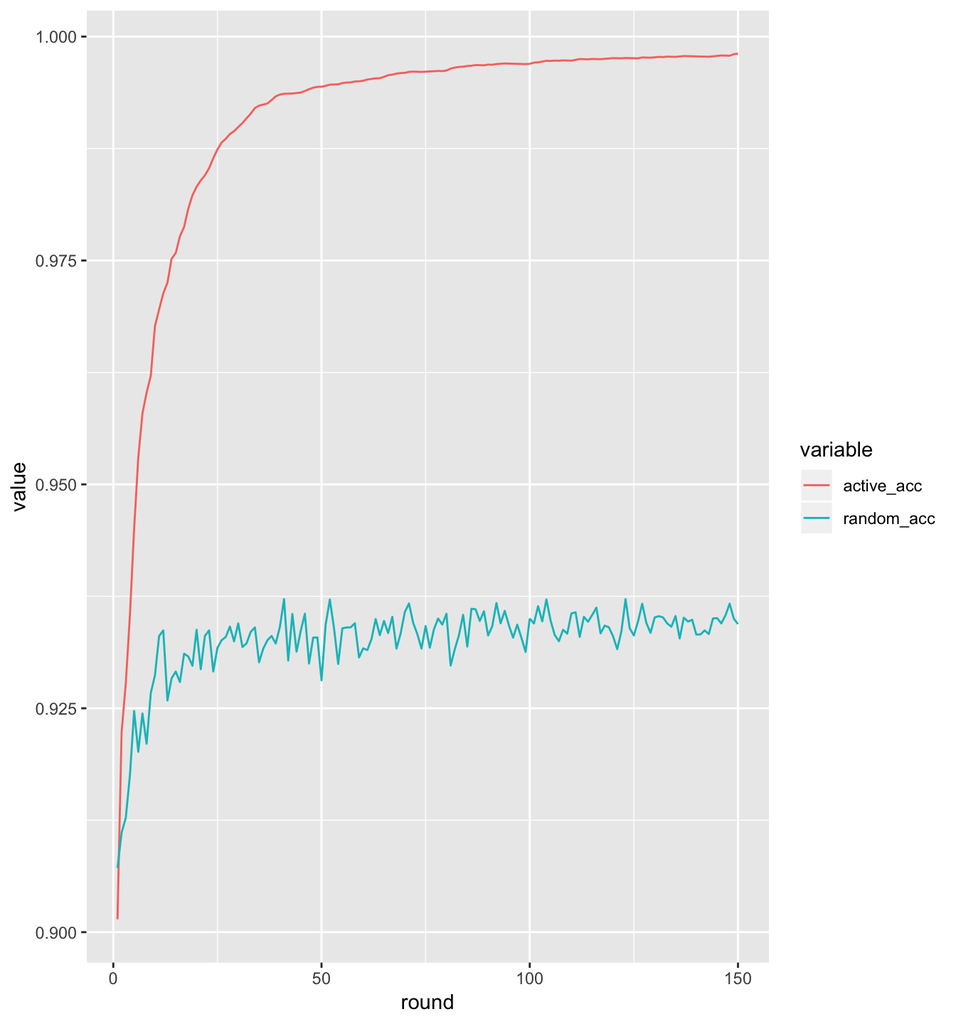

```r
colnames(active_accuracy_table) <- c("round_act", "active_acc")
colnames(random_accuracy_table) <- c("round_rand", "random_acc")

ttl_acc <- cbind(active_accuracy_table, random_accuracy_table) %>% na.omit()
ttl_acc <- ttl_acc %>% select(-round_act)
ttl_acc <- ttl_acc %>% select(-round_rand)
round <- c(1:150)
ttl_acc <- cbind(round, ttl_acc)

ttl_acc_long <- melt(ttl_acc, id = "round")
ggplot(data = ttl_acc_long, aes(x=round, y=value, color = variable)) + geom_line()
```